# Problem Structure & Findings

## Problem Structuring | Ask & Value

**The ask:** :

- Create an engine that generates **individual level forecasts** for number of orders and total value for a fixed time period.

**The value** :

- **Maximize customer lifetime value** via potential churn indication and prescriptive campaigns, and/or
- provide forecasts for other business interests such as **revenue forecast reports**.

## Pre modeling findings - Orders distiribution

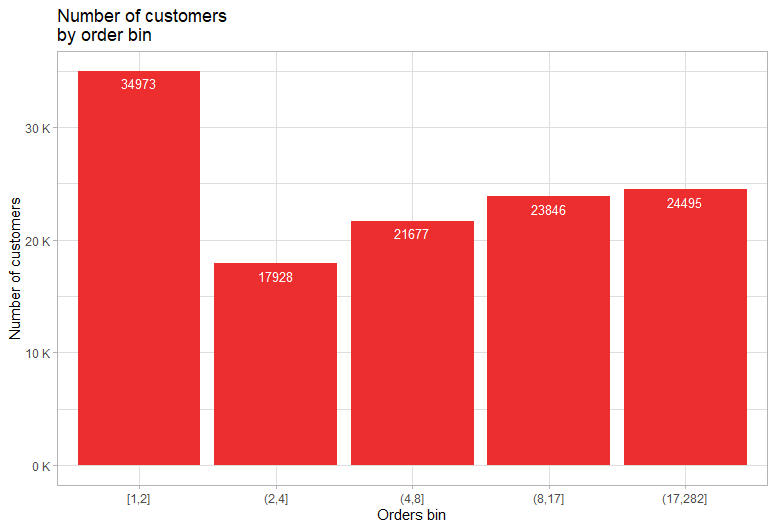

## Pre modeling findings - Forecast eligibility

Taking into account the fact many customers have 1 or 2 orders in total we decided to differentiate our approach by providing naive forecasts for those low activity users.

Setting as threshold the *60% quantile* which corresponds to value *8* orders, all above threshold users will be analyzed with the help of the probabilistic methodology to be described later.

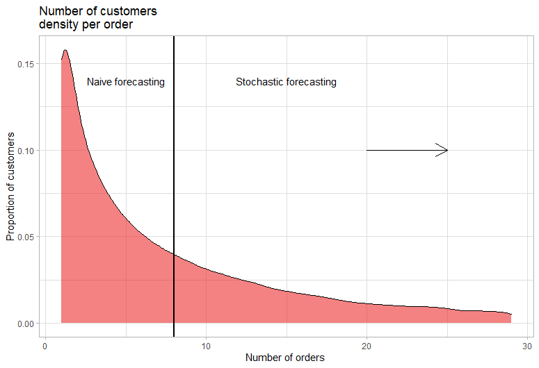

## Pre modeling Findings - Vertical Importance

Another important finding is the vast difference in terms of behavior between different verticals. Therefore, we will also analyze verticals separately and merge back to a total customer level as a last step of the analysis.

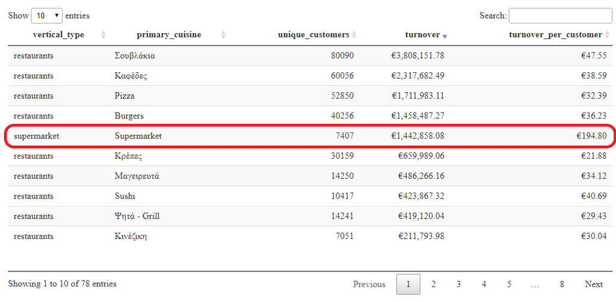

# Methodology

Instead of approaching this problem with a time series methodology, given that number of orders are :

- Mostly taking values 0,1,2,3 per day
- Are directly related with total value

we decided to structure a multi-class classification problem and produce forecasts with the help of Multinomial Naive Bayes classifiers. A simple but, in our view, very powerful supervised learning algorithm for such problems.

## Methodology Diagram

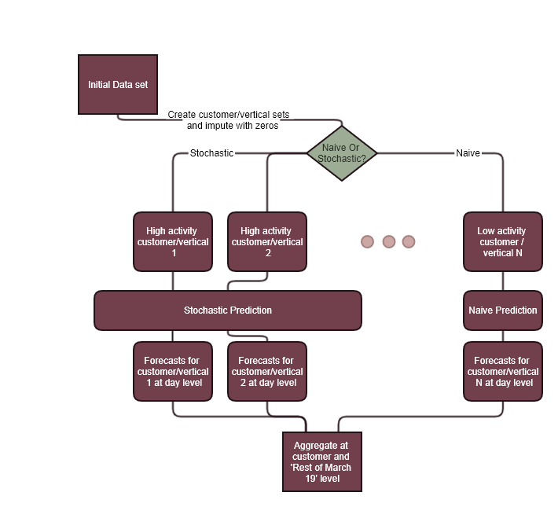

## Feature Engineering

We constructed chronological features that we can project ahead (forecast set) such as :

- Day of week
- Week number in month

We excluded variables from the independent space we cannot utilize in the forecast set unless we will predict them independently. We would like to avoid that to reduce model uncertainty.

## Assumptions

We made a series of assumptions throughout the modeling phase:

- Zero imputations for days missing from the customer level data set.
- Where 10-k fold cross validation with MAPE as an optimization criterion was not possible due to lack of classes we trained the classifier to the full customer/vertical training set without hyper parameter tuning.
- For users with less than 8 orders in total we used naive forecasts of the average behavior.
- Total order value forecast is a byproduct of number of orders forecast multiplied by the average order value for each customer.

## Data Modeling

As said the supervised learning conditional probability algorithm of Naive Bayes was utilized to predict the daily number of orders per customer.

See below a glimpse of the training set and the prediction set:

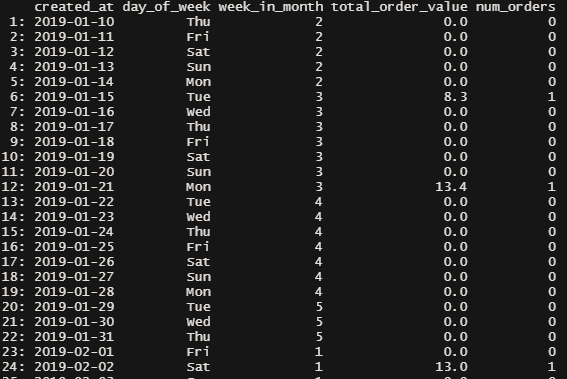

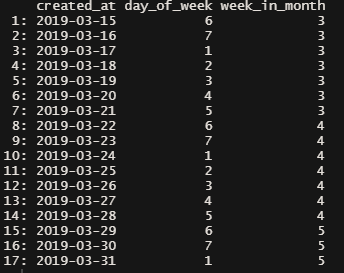

## Technology

We choose **R language** to tackle this problem since initially it looked like a time series analysis that could be adressed with either a traditional probabilistic model (poisson count regression) or mean and variance model (ARIMA , GARCH).

Since the NB implementation of **caret** package was sufficient we did not switch to **Python**.

# Results validation & suggested improvements

## Results

We produced diagnostic visuals for two randomly selected users:

- Line chart of actual time series of orders
- Bar chart with number of days per order class (x days with 0 orders, 1 order…)
- Bar chart with number of days per order class in forecast period
- Line chart of actual time series of orders & forecasts

We do not have a chart of actual vs predicted for a test period within the training set since we allowed for a 10 k-fold cross validation with MAPE optimization.

## User 1

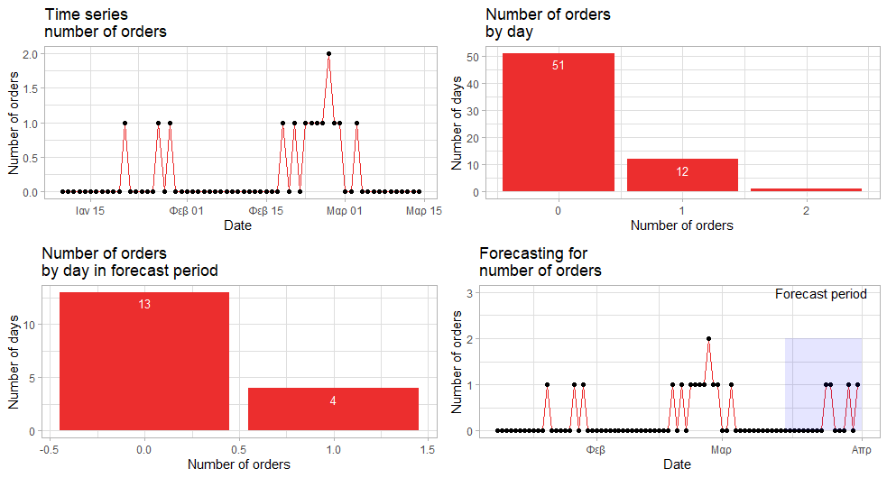

## User 2

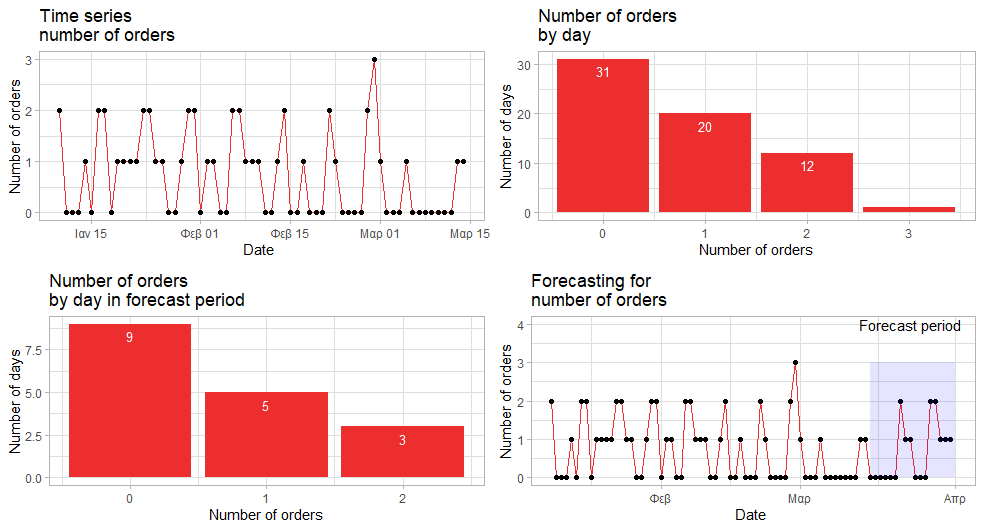

## Improvements

This demo work is subject to many improvements such as :

- A collective approach could be taken to predict low activity users, such as similarity clustering.
- The computationally intense tasks were tackled with native R packages for multi core computations. This could be greatly improved.
- A deeper analysis on verticals as well as cities & postcodes could yield richer insights before modeling.
- Heat maps could be used to visualize confusion matrices.